# Projekt 1, faza 3

Julia Herman-Iżycka, Bartosz Sajniak, Jakub Tyrek, Rafał Zaborowski

27 kwietnia 2016

# 1. Spis treści

- 1. Spis treści
- 2. Przygotowanie danych
- 3. Porównanie czasu spędzonego na różnych stacjach
- 4. Odległość pomiędzy stacjami
- 5. Określanie liczby klastrów
  - 5.1. Średnia sylwetka
  - 5.2. Gap statistic
- 6. Odległości stacji
- 7. Częste połączenia w ścieżkach
- 8. Analiza ścieżek - jak ludzie poruszają się po wystawie?
  - 8.1. Przygotowanie ścieżki
  - 8.2. MDS
  - 8.3. Klastrowanie ścieżek
  - 8.4. Stacje w klastrach ścieżki
- 9. Popularność krótkich ścieżek
  - 9.1. Ścieżki długości jeden
  - 9.2. Ścieżki długości dwa
  - 9.3. Ścieżki długości trzy
- 10. Początek i koniec zwiedzania
- 11. Macierz przejścia
- 12. Klasteryzacja stacji ze względu prawdopodobieństwa przejścia
- 13. Przejście - “most”
- 14. Reguły asocjacyjne

# 2. Przygotowanie danych

Przygotowanie danych zaczniemy od oczyszczenia ich z informacji, które nie są ciekawe do analizy. Następnie poniższy kod liczy czas odwiedzin poszczególnych odwiedzających na pojedynczej stacji. Zauważmy także, że niektóre wizyty w naszych danych są nienaturalnie długie. W związku z tym pozbądźmy się wizyt, które trwają dłużej niż 10^4.

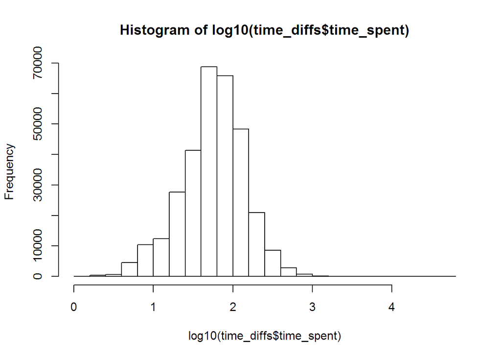

```r
smallLogs <- smallLogs %>% filter(visitor != -1)
smallLogs$visitor_change <- smallLogs$visitor != lag(smallLogs$visitor) | as.Date(smallLogs$date) != as.Date(lag(smallLogs$date)) | smallLogs$station != lag(smallLogs$station)

smallLogs$visitor_change[1] <- FALSE
smallLogs$visit_id <- cumsum(smallLogs$visitor_change)

time_diffs <- smallLogs %>% group_by(visit_id, station, visitor) %>% summarise(enter_time = first(date), leave_time = last(date), time_spent = leave_time - enter_time)

time_diffs$station <- factor(time_diffs$station)
time_diffs <- time_diffs %>% as_data_frame() %>% mutate(visitor_id = paste(visitor,  as.Date(enter_time), sep='_'))

hist(log10(time_diffs$time_spent))
```

```r
#filter unusually long times
upper_limit <- 10^4
time_diffs <- time_diffs  %>% filter(time_spent <= upper_limit)
```

# 3. Porównanie czasu spędzonego na różnych stacjach

Zbadajmy czy profile czasu spędzonego na różnych stacjach są różne? Jeżeli tak, to czy można tych różnic użyć do klastrowania?

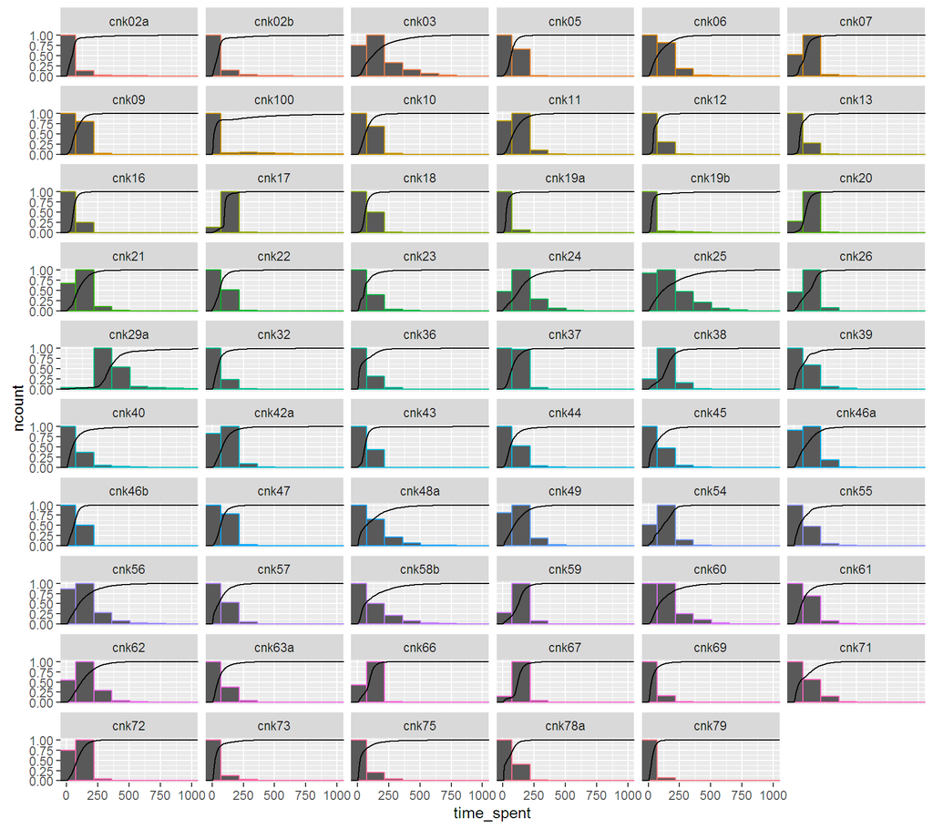

```r
time_spent <- aggregate(time_diffs$time_spent,list(time_diffs$visitor),median)

colnames(time_spent) <- c('visitor','mean_time_spent_visiting')

ggplot(time_diffs,aes(time_spent)) + geom_histogram(aes(y=..ncount..,colour=station, guided=FALSE),bins=70) + stat_ecdf() + facet_wrap(~ station,ncol=6) + coord_cartesian(xlim=c(0,1000)) + guides(colour=FALSE)
```

# 4. Odległość pomiędzy stacjami

Można zauważyć, że odpowiedź na pytanie o różnicę czasu spędzonego na różnych stacjach jest twierdząca. Spróbujmy zatem tę różnicę wykorzystać za pomocą statystyki Kołmogorowa-Smirnowa i policzmy odległości.

```r
visit_time_range <- range(time_diffs$time_spent)
min_vt <- visit_time_range[[1]]
max_vt <- visit_time_range[[2]]
range_vt <- seq(min_vt,max_vt,by = 1)

by_station <- split(time_diffs$time_spent,time_diffs$station,drop=TRUE)
by_station_ecdf <- lapply(by_station, function(x){return(ecdf(x)(range_vt));})

dist_KS_mtx <- Vectorize(function(i,j){
  v1 <- by_station_ecdf[[i]];
  v2 <- by_station_ecdf[[j]];
  kst <- ks.test(v1,v2);
  s <- kst$statistic;
  names(s) <- NULL;
  return(s);
})

dist_mtx <- outer(1:length(by_station_ecdf),1:length(by_station_ecdf),dist_KS_mtx)

station_names <- time_diffs %>% distinct(station) %>% dplyr::select(station)
```

# 5. Określanie liczby klastrów

Chcielibyśmy użyć tej odległości do klastrowania, sprawdźmy zatem ile klastrów powinno być.

### 5.1. Średnia sylwetka

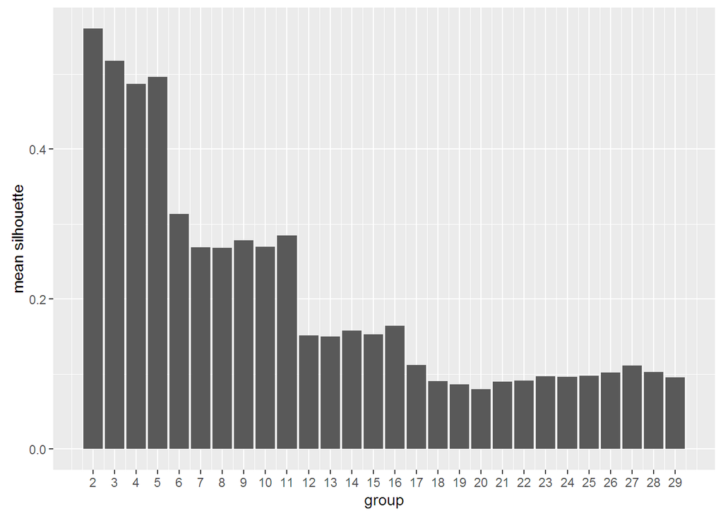

```r
sils <- data.frame()
for(i in 2:(nrow(dist_mtx)/2)){
  paths_pam <- pam(dist_mtx, i);
  sil <- silhouette(paths_pam$clustering,dist_mtx);
  sils <- rbind(sils,data.frame(group=i,mean_silhouette=mean(sil[,"sil_width"]),std_silhouette=sd(sil[,"sil_width"])));
}

ggplot(sils,aes(group,mean_silhouette)) + geom_bar(stat="identity") + scale_x_continuous(breaks = seq(2,29,1)) + ylab("mean silhouette")
```

### 5.2. Gap statistic

```r
library("factoextra")
```

```r
clusters_eclust <- eclust(dist_mtx,"agnes",graph=FALSE)
data.frame(station=station_names$station, cluster=clusters_eclust$cluster)
```

```
##    station cluster
## 1   cnk02a       1
## 2   cnk02b       2
## 3    cnk03       2
## 4    cnk05       3
## 5    cnk06       4
## 6    cnk07       3
## 7    cnk09       5
## 8   cnk100       6
## 9    cnk10       3
## 10   cnk11       5
## 11   cnk12       5
## 12   cnk13       5
## 13   cnk16       5
## 14   cnk17       5
```

[output cut: 45 more lines]

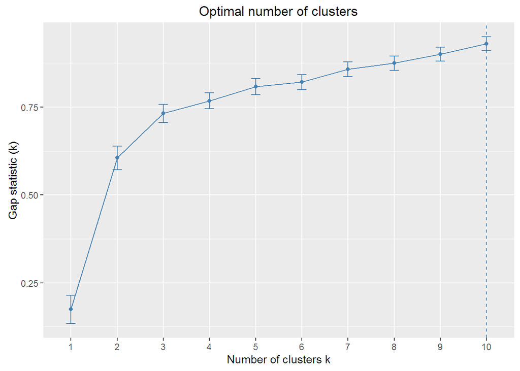

```r
fviz_gap_stat(clusters_eclust$gap_stat)
```

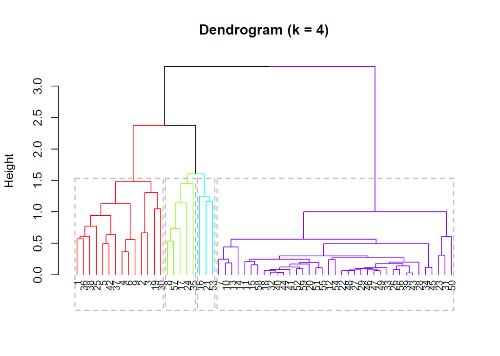

```r
clusters <- agnes(dist_mtx)
fviz_dend(clusters, k = 4, rect = TRUE, main = "Dendrogram (k = 4)")
```

# 6. Odległości stacji

Mamy już odległości, spróbujmy więc zwizualizować otrzymane za pomocą powyższych punktów informacje używajac w tym celu PCA. Policzmy także wariancje zachowaną żeby zobaczyć jakość rysunku, klastruje używajac algorytmu pam.

```r
station_pca <- cmdscale(dist_mtx, eig = TRUE)
print((station_pca$eig[1] ^ 2 + station_pca$eig[2] ^ 2) / (sum(sapply(station_pca$eig, function(x) x ^ 2))))
```

```
## [1] 0.9427717
```

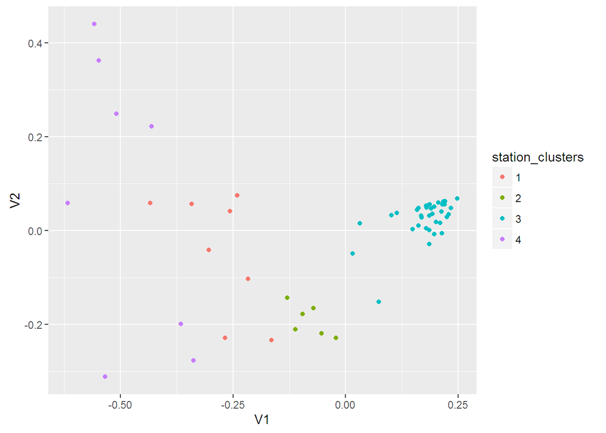

```r
station_pam <- pam(dist_mtx, 4)
station_clusters <- sapply(station_pam$clustering, toString)
ggplot(as.data.frame(station_pca$points), aes(V1, V2)) + geom_point(aes(color = station_clusters))
```

```r
station_names <- station_names %>% mutate(cluster = station_clusters)
time_diffs <- time_diffs %>% mutate(station_cluster = plyr::mapvalues(station, as.vector(station_names$station), as.vector(station_names$cluster)))
```

Histogram czasu spędzonego na stacjach z odpowiednich klastrów.

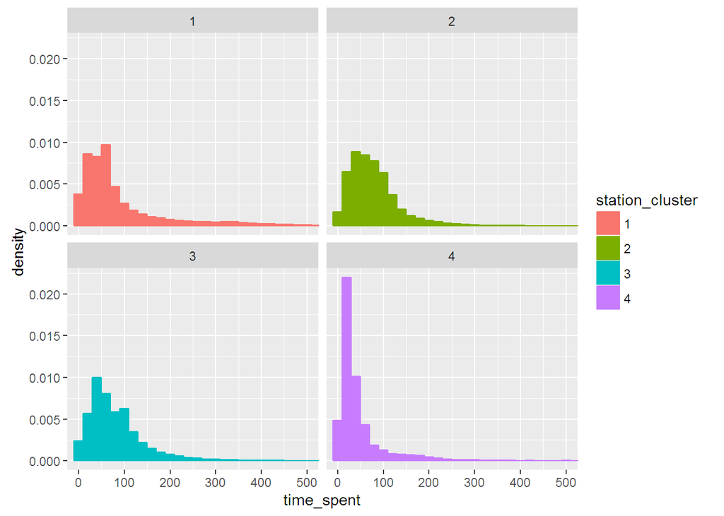

```r
ggplot(time_diffs, aes(time_spent, color = station_cluster, fill = station_cluster)) + geom_histogram(aes(y = ..density..), bins = 500) + facet_wrap(~station_cluster) + coord_cartesian(xlim = c(0, 500))
```

Aby zobaczyć które klastry mają przewagę dokonujemy sumowania i normalizujemy.

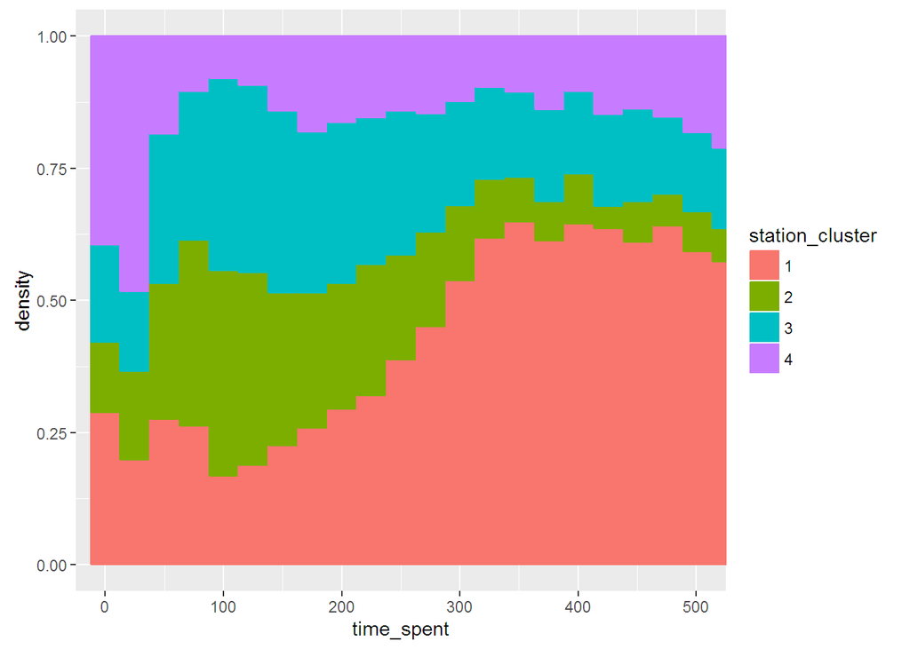

```r
ggplot(time_diffs, aes(time_spent, color = station_cluster, fill = station_cluster)) + geom_histogram(aes(y = ..density..), bins = 400, position = 'fill') + coord_cartesian(xlim = c(0, 500))
```

Rzeczywiście na powyższym rysunku można zobaczyć, że rozkład czasu spędzonego różni się.

# 7. Częste połączenia w ścieżkach

Zobaczmy prawdopodobieństwo pojedynczego kroku najczęstszych połączeń między stacjami, w tym celu liczymy prawdopodobieństwo warunkowe. Widać, że eksponat numer 19(a - wejście, b - wyjście) słusznie nazywa się Salą Strachów, ponieważ tylko część osób po wejściu do niej wychodzi odpowiednim wyjściem. Jednocześnie ścieżka ta: 19a -> 19b ma największe prawdopodobieństwo warunkowe.

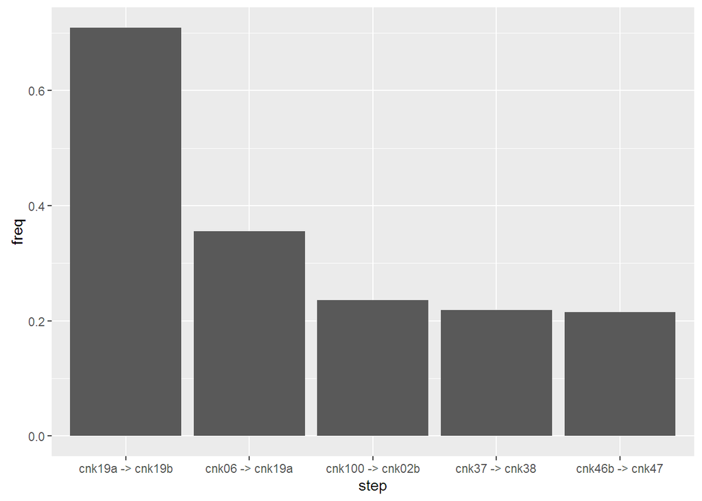

```r
time_diffs <- time_diffs %>% arrange(visitor, enter_time)
time_diffs$day_or_visitor_changed <- as.Date(time_diffs$enter_time) != as.Date(lag(time_diffs$enter_time)) | time_diffs$visitor != lag(time_diffs$visitor)
time_diffs$day_or_visitor_changed[1] <- FALSE

time_diffs$prev_station <- lag(time_diffs$station)
time_diffs <- time_diffs %>% mutate(prev_station = replace(prev_station, day_or_visitor_changed, NA))

vis_seq <- time_diffs %>% filter(!is.na(prev_station)) %>% group_by(prev_station, station) %>% summarise(n = n()) %>% mutate(freq = n / sum(n))
vis_seq <- vis_seq %>% ungroup() %>% dplyr::arrange(desc(freq)) %>% dplyr::slice(1:5)
vis_seq <- vis_seq %>% transmute(step = paste(prev_station, station, sep = ' -> '), freq = freq)
vis_seq <- vis_seq %>% mutate(step = factor(step, levels = vis_seq$step[order(freq, decreasing = T)]))

ggplot(vis_seq, aes(step, freq)) + geom_bar(stat = 'identity')
```

# 8. Analiza ścieżek - jak ludzie poruszają się po wystawie?

### 8.1. Przygotowanie ścieżki

Każdej stacji przyporządkowujemy unikalny znak, dzięki czemu scieżka to ciag znaków. Powinniśmy również wykluczyć ścieżki, które mają mniej niż 10 znaków.

```r
station_names <- time_diffs %>% distinct(station) %>% dplyr::select(station)
station_names <- station_names %>% mutate(station_char = c(letters, LETTERS, 1:7)) #na sztywno

time_diffs <- time_diffs %>% ungroup() %>% arrange(visitor, enter_time)
time_diffs <- time_diffs %>% mutate(station_char = plyr::mapvalues(station, as.vector(station_names$station), as.vector(station_names$station_char)))

paths <- time_diffs %>% group_by(visitor, date = as.Date(enter_time)) %>% summarise(path = paste(station_char, collapse = ''))
paths <- paths %>% mutate(n = nchar(path))
```

Odległość między ścieżkami definiujemy jako odleglość podstawieniową dwóch ciągów znaków. Tablica podstawień jest generowana przez odległość stacji z poprzedniej analizy. Aby klastrowanie nie zależało od długości sciezek wybieramy scieżki długosci 10. Wybierzmy także losową próbkę aby macierz odległości nie była zbyt duża.

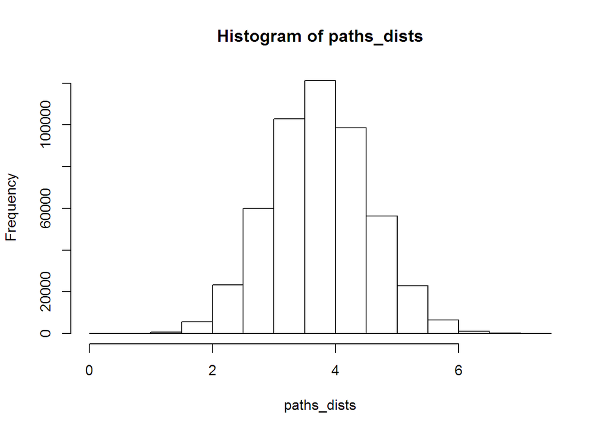

```r
paths2 <- paths %>%  filter(n == 10) %>% ungroup() %>% sample_n(size=1000)

row.names(dist_mtx) <- station_names$station_char
colnames(dist_mtx) <- station_names$station_char

paths_dists <- stringDist(paths2$path,method="substitutionMatrix",
  substitutionMatrix = dist_mtx
)

hist(paths_dists)
```

### 8.2. MDS

Wykonujemy niemetryczne skalowanie wielowymiarowe i wyświetlamy za pomocą funkcji Shepard.

```r
newcoord <- isoMDS(as.dist(paths_dists))
```

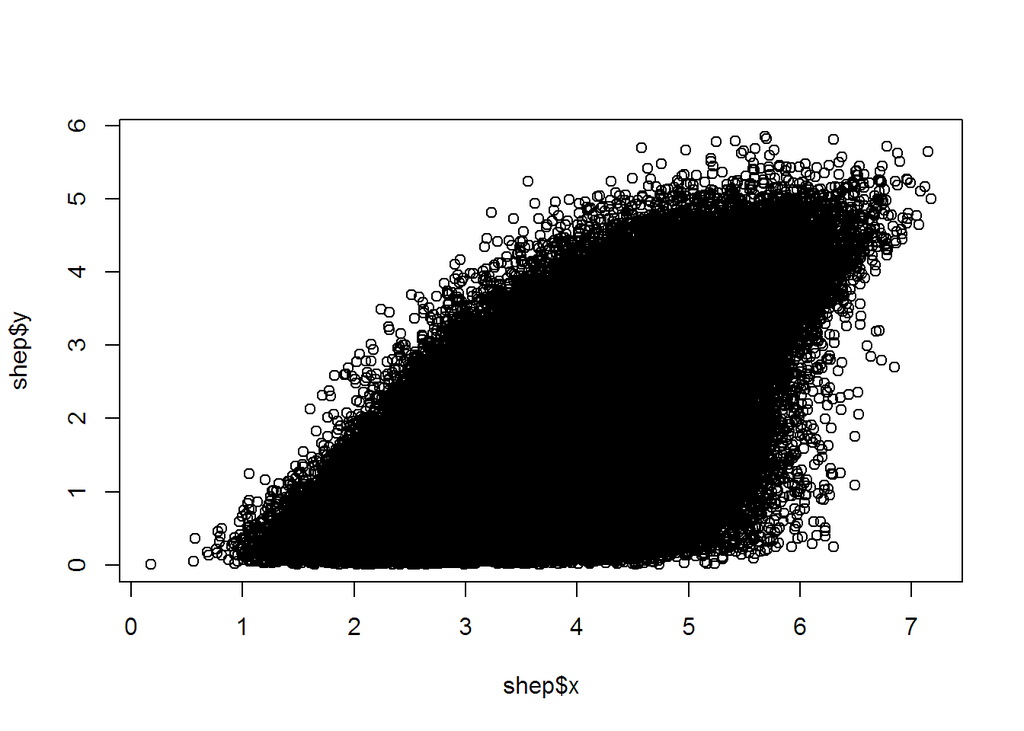

```r
#plot(newcoord$points)

shep <- Shepard(paths_dists, newcoord$points)
plot(shep)
```

```r
df2 <- data.frame(x = newcoord$points[,1], y = newcoord$points[,2])
```

### 8.3. Klastrowanie ścieżek

Spróbujmy użyć klastrowania za pomocą algorytmu pam, a także zwizualizować dane. Jak widzimy jest to niskiej jakości, więc nie jest za bardzo pouczające.

```r
#k-medoids
kmedoids <- pam(paths_dists, 4)
df2$cluster <- as.factor(kmedoids$clustering)

print(paths2[kmedoids$medoids,])
```

```
## Source: local data frame [4 x 4]
##
##   visitor       date       path     n
##     (chr)     (date)      (chr) (int)
## 1  834610 2012-01-24 R2rW4JEZjj    10
## 2  861608 2012-02-07 atU67wv3Oz    10
## 3  897624 2012-02-25 3aU67Ywbz3    10
## 4  887499 2012-02-21 v67wcRzz63    10
```

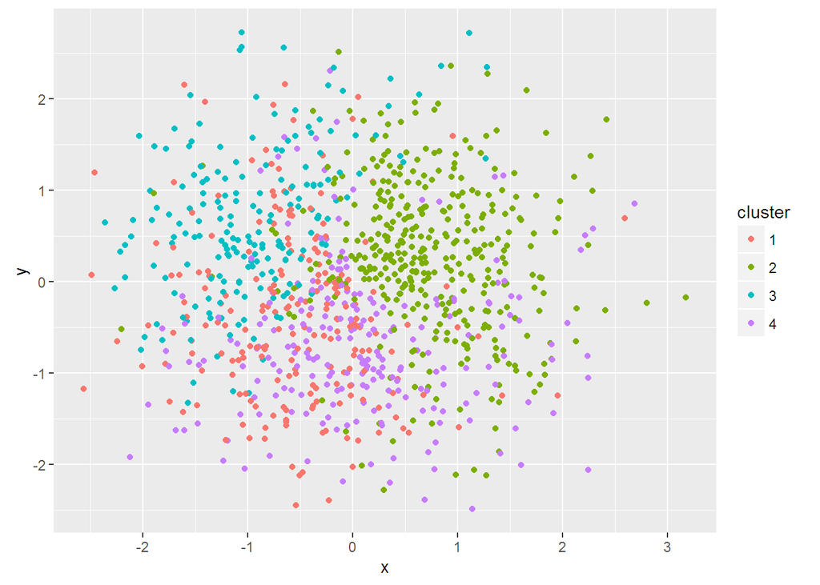

```r
ggplot(df2, aes(x=x, y=y)) + geom_point(aes(color=cluster))
```

```r
#hierarchical clustering
tree1 <- agnes(paths_dists, method = "ward")
clusters <- factor(cutree(tree1, 4))

summary(clusters)
```

```
##   1   2   3   4
## 164 341 149 346
```

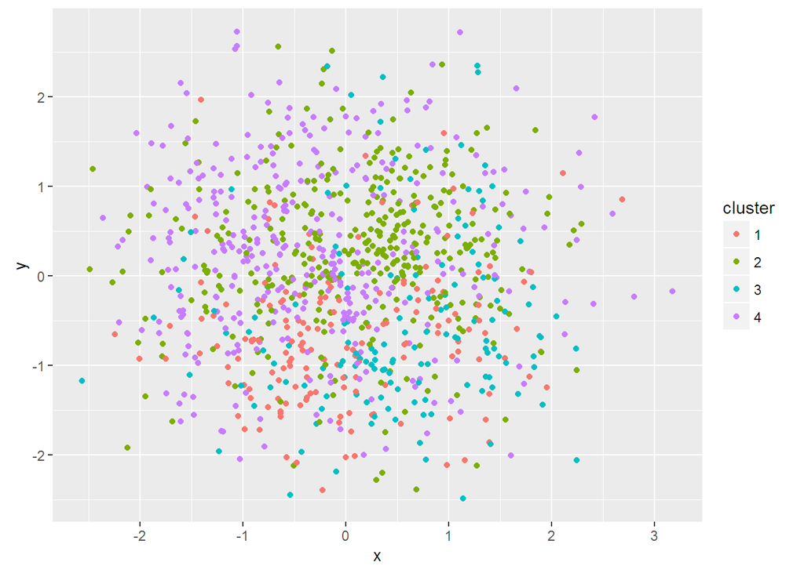

```r
df2$cluster <- clusters
ggplot(df2, aes(x=x, y=y)) + geom_point(aes(color=cluster))
```

### 8.4. Stacje w klastrach ścieżki

Sprawdźmy teraz czy klastry się czymś różnią, w tym celu sprawdźmy jakie stacje odwiedzali ludzie przechodzący ścieżki w klastrach. Jak często występuję pojedyncza stacja w ścieżkach z klastrami?

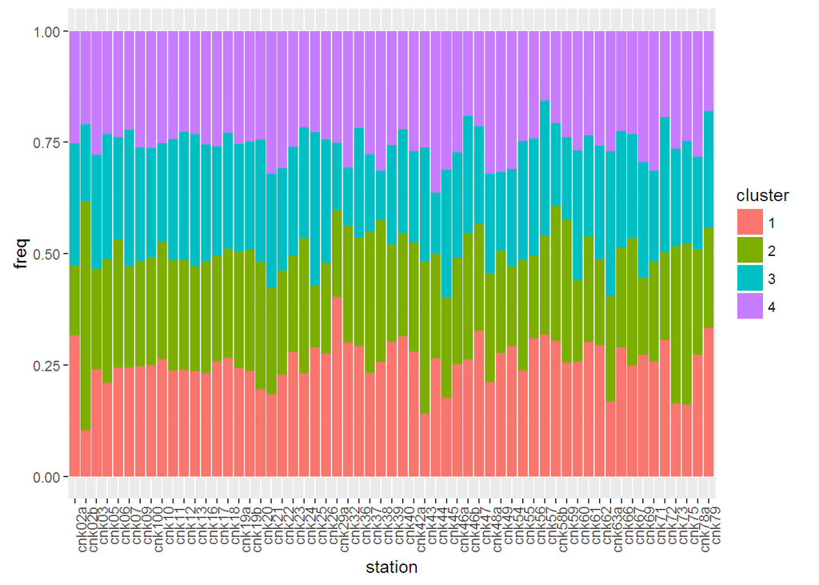

```r
get_freq_ch <- function(st_ch){
  paths2 <- paths2 %>% mutate(got_st_ch = grepl(st_ch, path), cluster = kmedoids$clustering)
  paths2_sum <- paths2 %>% group_by(cluster) %>% summarise(ch_freq = sum(got_st_ch) / n())
  return(paths2_sum$ch_freq)
}

ch_freqs <- c()
for(i in 1:dim(station_names)[1]){
  t1 <- c(get_freq_ch(station_names[i,2]))
  ch_freqs <- rbind(ch_freqs, t1)
}

colnames(ch_freqs) <- 1:4
ch_freqs <- as.data.frame(ch_freqs)
ch_freqs$station <- station_names$station
ch_freqs <- gather(ch_freqs, cluster, freq, 1:4)

ggplot(ch_freqs, aes(station, freq)) + geom_bar(position = 'fill', stat = 'identity', aes(fill = cluster)) + theme(axis.text.x = element_text(angle = 90, hjust = 1))
```

# 9. Popularność krótkich ścieżek

### 9.1. Ścieżki długości jeden

Spróbujmy odpowiedzieć sobie na pytanie z jakich stacji korzystają ludzie, którzy odwiedzili małą liczbę eksponatów. Zacznijmy od tych, którzy odwiedzili tylko jeden z nich(przeszli ścieżkę długości jeden) - pierwszy wykres są to najczęściej odwiedzane eksponaty przez tych ludzi, a drugi najrzadziej.

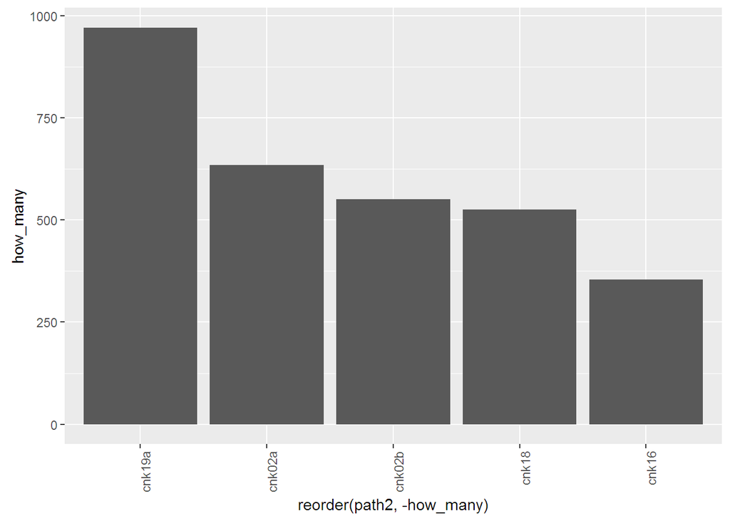

```r
paths2 <- time_diffs %>% group_by(visitor, date = as.Date(enter_time)) %>% summarise(path2 = paste(station, collapse = '->'))
paths$path2 <- paths2$path2
paths1 <- paths %>% filter(n == 1)
paths1 <- paths1 %>% group_by(path2) %>% summarise(how_many = n()) %>% arrange(how_many)

ggplot(tail(paths1, 5), aes(reorder(path2, -how_many), how_many)) + geom_bar(stat = 'identity') + theme(axis.text.x = element_text(angle = 90, hjust = 1))
```

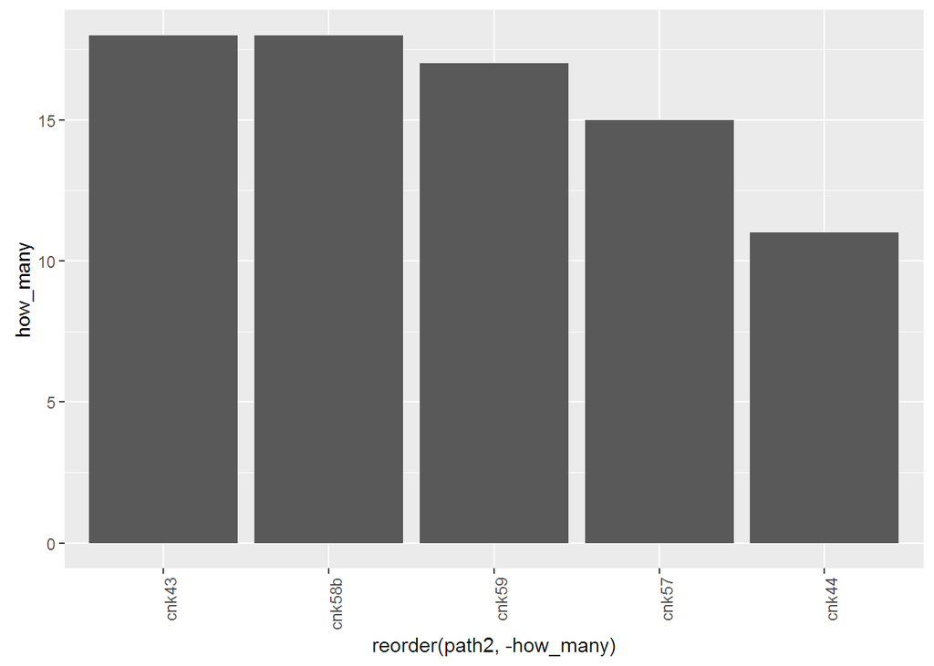

```r
ggplot(head(paths1, 5), aes(reorder(path2, -how_many), how_many)) + geom_bar(stat = 'identity') + theme(axis.text.x = element_text(angle = 90, hjust = 1))
```

### 9.2. Ścieżki długości dwa

Skoro wiemy jakie stacje sa odwiedzane przez ludzi, którzy odwiedzają tylko jeden z dostępnych eksponatów to sprawdźmy jak “chodzą” ludzie, którzy dwukrotnie korzystają z dostępnych eksponatów.

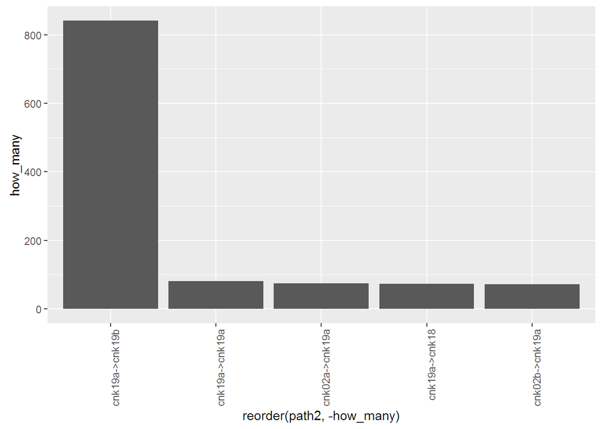

```r
paths1 <- paths %>% filter(n == 2)
paths1 <- paths1 %>% group_by(path2) %>% summarise(how_many = n()) %>% arrange(how_many)

ggplot(tail(paths1, 5), aes(reorder(path2, -how_many), how_many)) + geom_bar(stat = 'identity') + theme(axis.text.x = element_text(angle = 90, hjust = 1))
```

### 9.3. Ścieżki długości trzy

Analogicznie do powyższych wykresów sprawdźmy teraz najpopularniejsze ścieżki długości trzy.

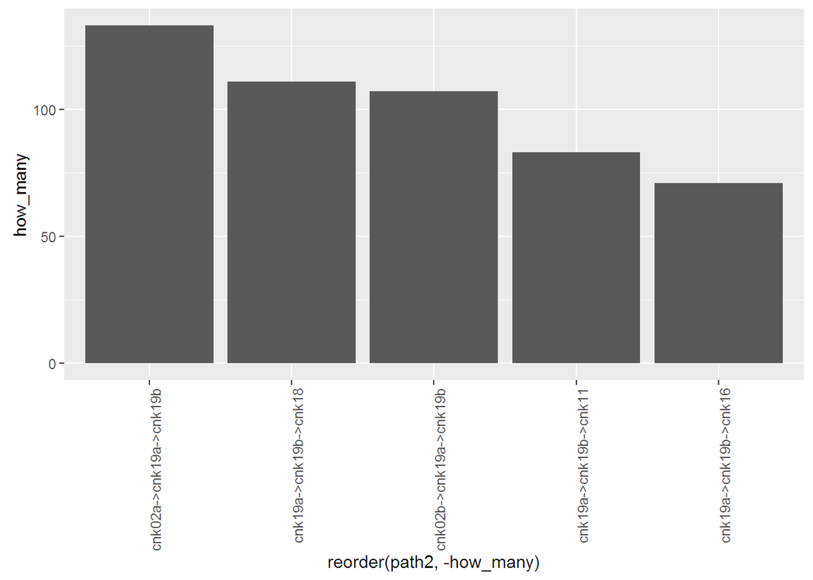

```r
paths1 <- paths %>% filter(n == 3)
paths1 <- paths1 %>% group_by(path2) %>% summarise(how_many = n()) %>% arrange(how_many)

ggplot(tail(paths1, 5), aes(reorder(path2, -how_many), how_many)) + geom_bar(stat = 'identity') + theme(axis.text.x = element_text(angle = 90, hjust = 1))
```

Widać, że stacja 19a, czyli wejście do Sali Strachów cieszy się dużym zainteresowaniem wśród ludzi, którzy przeszli ścieżkę długości 1, 2 oraz 3. Co więcej wśród ścieżek długości 2 drugą najpopularniejszą ścieżką jest dwukrotne wejście do Sali Strachów. Zgodnie z intuicją, najpopularniejsze krótkie ścieżki znajdują się blisko wejścia.

# 10. Początek i koniec zwiedzania

Sprawdźmy jak ludzie zaczynają i kończą zwiedzanie.

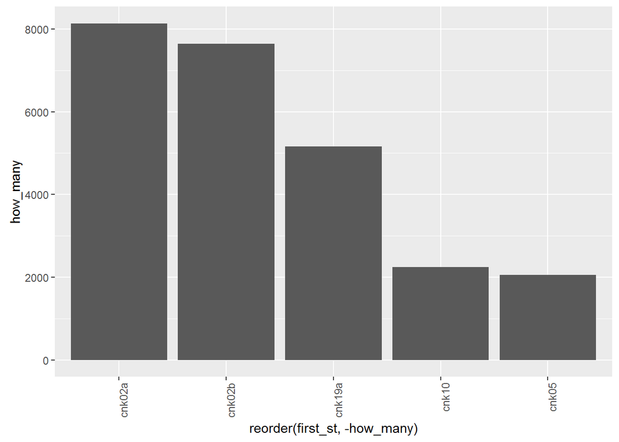

```r
paths1 <- time_diffs %>% ungroup() %>% group_by(visitor) %>% arrange(enter_time) %>% summarise(first_st = first(station)) %>% dplyr::select(first_st)
paths1 <- paths1 %>% group_by(first_st) %>% summarise(how_many = n()) %>% ungroup() %>% arrange(how_many)

ggplot(tail(paths1, 5), aes(reorder(first_st, -how_many), how_many)) + geom_bar(stat = 'identity') + theme(axis.text.x = element_text(angle = 90, hjust = 1))
```

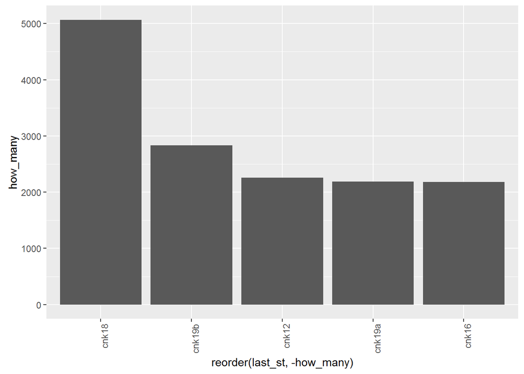

```r
paths1 <- time_diffs %>% ungroup() %>% group_by(visitor) %>% arrange(enter_time) %>% summarise(last_st = last(station)) %>% dplyr::select(last_st)
paths1 <- paths1 %>% group_by(last_st) %>% summarise(how_many = n()) %>% ungroup() %>% arrange(how_many)

ggplot(tail(paths1, 5), aes(reorder(last_st, -how_many), how_many)) + geom_bar(stat = 'identity') + theme(axis.text.x = element_text(angle = 90, hjust = 1))
```

# 11. Macierz przejścia

Policzmy najpierw macierz przejścia.

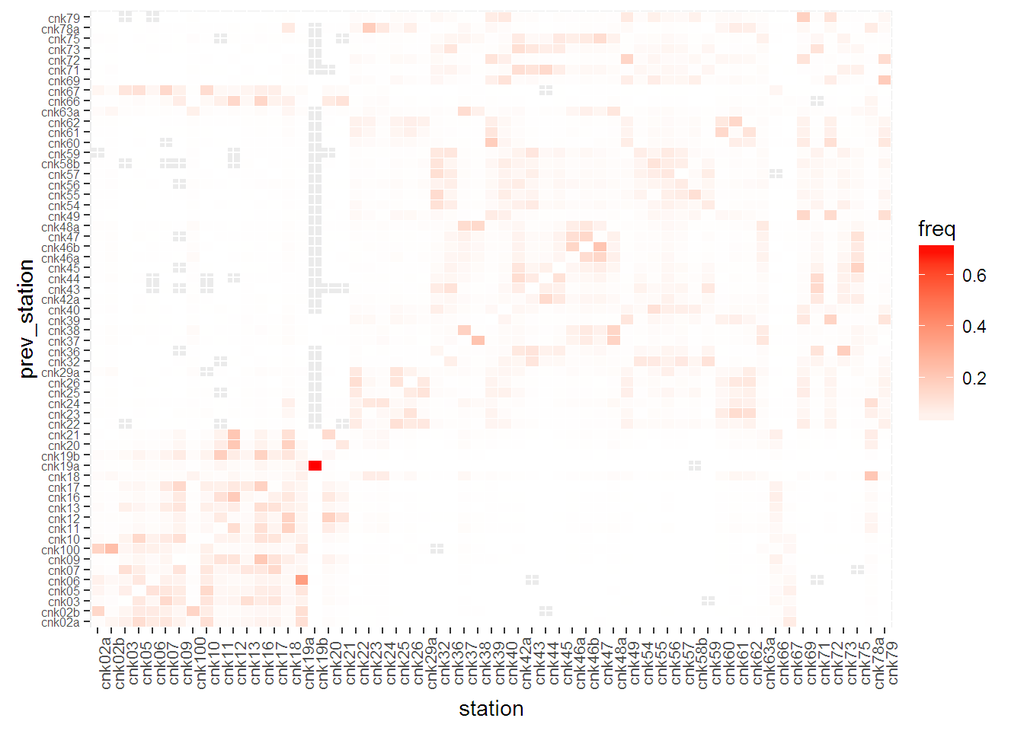

```r
time_diffs <- time_diffs %>% ungroup() %>% arrange(visitor, enter_time)
time_diffs$day_or_visitor_changed <- as.Date(time_diffs$enter_time) != as.Date(lag(time_diffs$enter_time)) | time_diffs$visitor != lag(time_diffs$visitor)
time_diffs$day_or_visitor_changed[1] <- FALSE
time_diffs$prev_station <- lag(time_diffs$station)
time_diffs <- time_diffs %>% mutate(prev_station = replace(prev_station, day_or_visitor_changed, NA))

vis_seq <- time_diffs %>% filter(!is.na(prev_station)) %>% group_by(prev_station, station) %>% summarise(n = n()) %>% mutate(freq = n / sum(n))

trans_m <- vis_seq %>% dplyr::select(prev_station, station, freq) %>% spread(station, freq)
row.names(trans_m) <- trans_m$prev_station
trans_m$prev_station <- NULL
trans_m[is.na(trans_m)] <- 0
trans_m <- as.matrix(trans_m)

ggplot(vis_seq, aes(station, prev_station)) + geom_tile(aes(fill = freq), colour = 'white') + scale_fill_gradient(low = "white", high = "red") + theme(axis.text.x = element_text(size = 8,angle=90), axis.text.y = element_text(size = 6))
```

# 12. Klasteryzacja stacji ze względu prawdopodobieństwa przejścia

Policzoną wcześniej macierz przejścia spróbujmy użyć do sklasteryzowania stacji w tym celu odległos między stacjami zdefiniujmy jako różnicę 2 i sumy prawdopodobieństw przejścia ze stacji A do B i odwrotnie. Spróbujmy zobaczyć na grafie jak wygląda nasza klasteryzacja. Użyjemy w tym celu algorytmu FR(Fruchterman-Reingold), który polega na tym, że każdy wierzchołek jest odpychającą się od siebie cząstką, a każda krawędź przyciąga łączone wierzchołki wprost proporcjonalnie do swojej wagi, w tym przypadku prawdopodobieństwa przejścia.

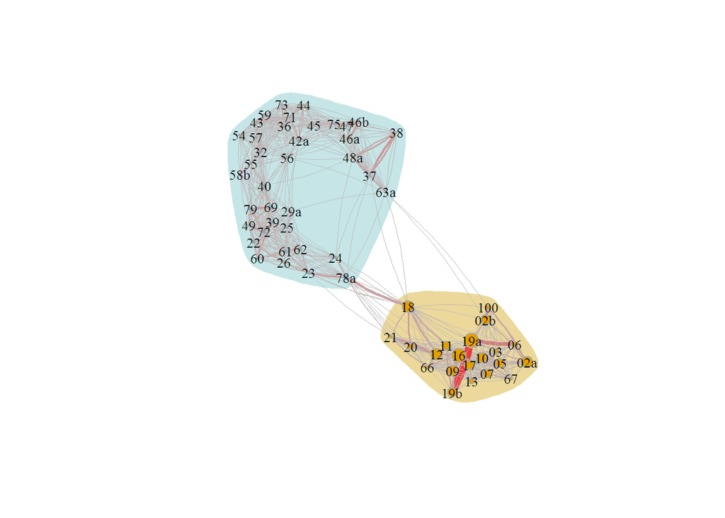

```r
station_names[,3] <- time_diffs %>% group_by(station) %>% summarise(n = n()) %>% dplyr::select(n)

st_dist <- trans_m + t(trans_m)
st_dist <- 2 - st_dist
clusters <- as.data.frame(pam(st_dist, 2)$clustering)

trans_graph <- function(treshold){

  nodes <- station_names %>% dplyr::select(station) %>% arrange(station)
  nodes$cluster <- clusters[,1]
  edges <- vis_seq %>% filter(freq >= treshold & prev_station != station)

  net <- graph.data.frame(d = edges, nodes, directed = T)
  V(net)$color <- V(net)$cluster
  layout <- layout_with_fr(net, weights = edges$freq)
  pal <- colorRampPalette(c("gray", "red"))(100)
  plot(net,
       edge.arrow.size = 0.5 * edges$freq,
       edge.color = pal[edges$freq * 100],
       vertex.size = station_names$n / 1500,
       layout = layout,
       vertex.shape = 'circle',
       vertex.label.cex = 0.8,
       vertex.frame.color = 'darkgray',
       vertex.label.color = 'black',
       edge.width = 10 * edges$freq,
       edge.curved = 0.1,
       edge.label.font = 2,
       vertex.label = as.vector(substring(nodes$station, 4)),
       mark.groups = list(which(V(net)$cluster == 2), which(V(net)$cluster == 1)),
       mark.col = c("#C5E5E7","#ECD89A"),
       mark.border = NA
    )
}
trans_graph(0.02)
```

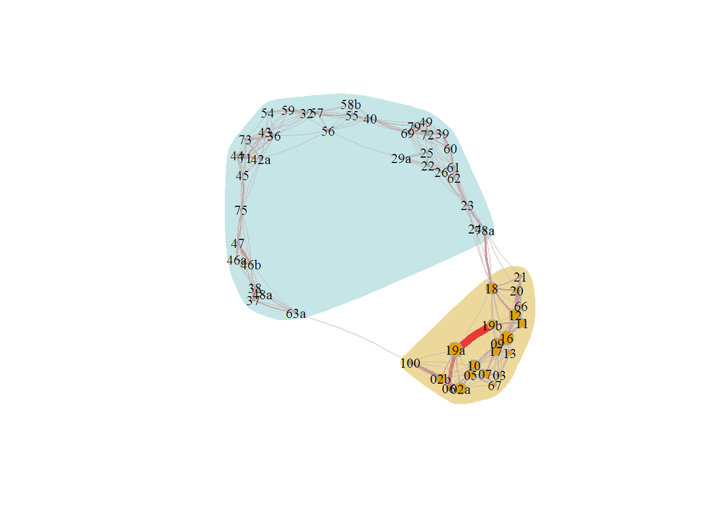

```r
trans_graph(0.05)
```

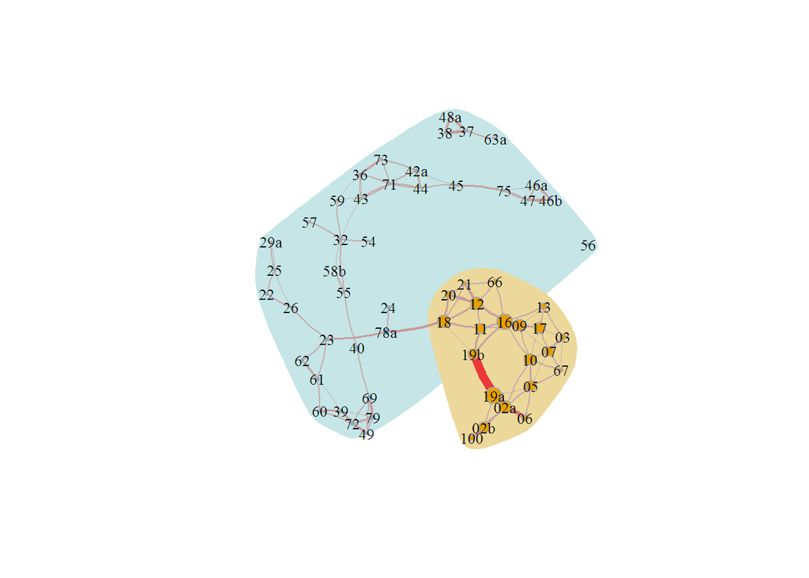

```r
trans_graph(0.09)
```

Na powyższych grafach pominięto krawędzie o wadze - kolejno: 0.02, 0.05 oraz 0.09. Można zauważyć także, że klasteryzacja ma sens, a swoistym mostem są stacje 18 i 78a. Zobaczmy jak ta klasteryzacja wygląda w rzeczywistości.

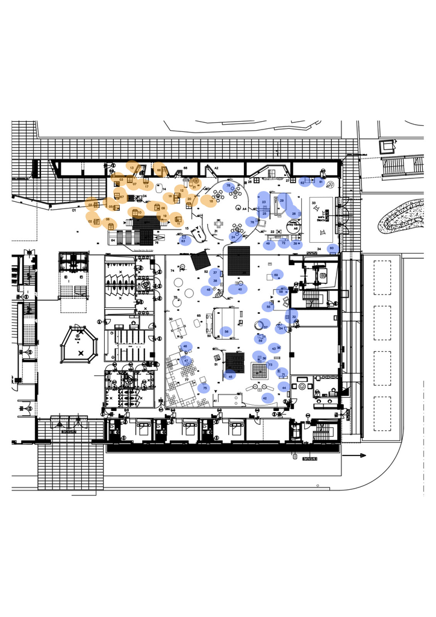

Na powyższym obrazku widać, że oba klastry są dosyć naturalnie rozdzielone.

# 13. Przejście - “most”

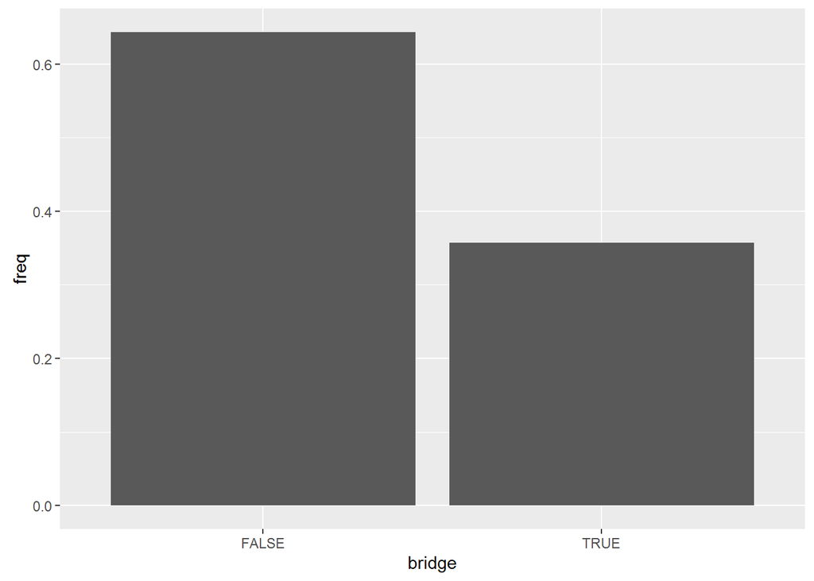

```r
station_names <- station_names %>% arrange(station)
station_names$cluster <- as.vector(clusters[,1])

time_diffs <- time_diffs %>% mutate(st_cl_p = plyr::mapvalues(station, as.vector(station_names$station), as.vector(station_names$cluster)))
time_diffs <- time_diffs %>% mutate(prev_st_cl_p = plyr::mapvalues(prev_station, as.vector(station_names$station), as.vector(station_names$cluster)))
time_diffs <- time_diffs %>% mutate(cluster_changed = st_cl_p != prev_st_cl_p)
time_diffs$cluster_changed[is.na(time_diffs$cluster_changed)] <- FALSE

cl_change <- time_diffs %>% filter(cluster_changed) %>% dplyr::select(prev_station, station)
cl_change <- cl_change %>% group_by(prev_station, station) %>% summarise(n =n())
cl_change <- cl_change %>% ungroup() %>% arrange(n)
cl_change <- cl_change %>% mutate(bridge = station == 'cnk78a' | station == 'cnk18' | prev_station == 'cnk78a' | prev_station == 'cnk18')

to_plot <- cl_change %>% group_by(bridge) %>% summarise(occ = sum(n))
to_plot$freq = to_plot$occ / sum(to_plot$occ)
ggplot(to_plot, aes(bridge, freq)) + geom_bar(stat = 'identity')
```

# 14. Reguły asocjacyjne

Mało czytelne badanie współwystępowania danych stacji w ścieżkach odwiedzających.

```r
transactions <- time_diffs %>% dplyr::select(visitor, station)
transactions$visited <- TRUE
transactions <- unique(transactions)

transactions <- spread(transactions, key = station, value = visited, fill = FALSE)
rownames(transactions) <- transactions$visitor
transactions$visitor <- NULL
tr_matrix <- transactions
tr_matrix$cnk19a <- NULL
tr_matrix <- as.matrix(tr_matrix)


transactions <- as(tr_matrix, "transactions")

rules <- apriori(transactions, parameter = list(support = 0.01))
```

```
## Apriori
##
## Parameter specification:
##  confidence minval smax arem  aval originalSupport support minlen maxlen
##         0.8    0.1    1 none FALSE            TRUE    0.01      1     10
##  target   ext
##   rules FALSE
##
## Algorithmic control:
##  filter tree heap memopt load sort verbose
##     0.1 TRUE TRUE  FALSE TRUE    2    TRUE
##
## Absolute minimum support count: 469
##
## set item appearances ...[0 item(s)] done [0.00s].
## set transactions ...[58 item(s), 46932 transaction(s)] done [0.02s].
## sorting and recoding items ... [58 item(s)] done [0.00s].
## creating transaction tree ... done [0.03s].
## checking subsets of size 1 2 3 4 5 6 7 done [0.13s].
## writing ... [68 rule(s)] done [0.00s].
## creating S4 object  ... done [0.00s].
```

```r
rules <- sort(rules, by = 'lift')
inspect(rules)
```

```
##    lhs                                      rhs     support    confidence
## 2  {cnk09,cnk20,cnk21,cnk66}             => {cnk12} 0.01016364 0.8548387
## 49 {cnk09,cnk10,cnk16,cnk17,cnk20}       => {cnk12} 0.01131424 0.8362205
## 41 {cnk07,cnk09,cnk10,cnk16,cnk20}       => {cnk12} 0.01129293 0.8359621
## 35 {cnk05,cnk07,cnk09,cnk16,cnk20}       => {cnk12} 0.01048325 0.8324873
## 43 {cnk05,cnk10,cnk16,cnk17,cnk20}       => {cnk12} 0.01035541 0.8307692
## 39 {cnk07,cnk09,cnk16,cnk17,cnk20}       => {cnk12} 0.01101594 0.8285256
## 45 {cnk05,cnk09,cnk16,cnk17,cnk20}       => {cnk12} 0.01058979 0.8283333
## 37 {cnk07,cnk10,cnk16,cnk17,cnk20}       => {cnk12} 0.01033410 0.8262351
## 47 {cnk05,cnk09,cnk10,cnk16,cnk20}       => {cnk12} 0.01144209 0.8248848
## 6  {cnk09,cnk16,cnk20,cnk21}             => {cnk12} 0.01133555 0.8235294
## 4  {cnk16,cnk17,cnk20,cnk21}             => {cnk12} 0.01046194 0.8224456
## 33 {cnk05,cnk07,cnk10,cnk16,cnk20}       => {cnk12} 0.01076025 0.8198052
## 21 {cnk05,cnk09,cnk11,cnk20}             => {cnk12} 0.01054717 0.8168317
## 5  {cnk10,cnk16,cnk20,cnk21}             => {cnk12} 0.01022756 0.8163265
```

[output cut: 123 more lines]

Podział pracy  
Julia Herman - Iżycka - przygotowanie danych, eksploracja danych, przygotowanie raportu 2 fazy, analiza ścieżek  
Bartosz Sajniak - eksploracja danych, przygotowanie raportu 3 fazy  
Jakub Tyrek - przygotowanie danych, eksploracja danych, analiza ścieżek, podsumowanie klastrów, most  
Rafał Zaborowski - przygotowanie danych, eksploracja danych, klastrowanie stacji, analiza klastrów